# Math 260 Project Data Description

Section: 1:20PM

Sandy Rosas, Pete Schultz & Tanush Samson

11/5/18

### Background

The videogame industry is a multi-billion dollar industry and a significant part of the world economy. We investigated certain trends and patterns within this industry to better understand it. The specific relationships we were interested in are American and Japanese sales, and console and genre. On top of this, we want to estimate the average number of global sales a video game has. From this we are able to better understand how large of an impact video games has on the global economy, learn which economy has a larger market for video games between the Americas and Japan, and to see if specific consoles favor specific genres of games more so than others .

### Methods

We obtained our data from an online dataset called “Video Game Sales with Ratings” by Rush Kirubi from www.kaggle.com.

### Results

**RELATIONSHIP 1**

$H_0: \rho = 0$  
$H_a: \rho > 0$  
where $\rho$ is the true population coefficient between Global Sales (in millions of units) and Critic Score for all video games.

We obtain sample correlation of r = 0.245 with a p-value of essentially 0. This means that assuming the null hypothesis is true (that there is no correlation between global sales and critic score), there is essentially a 0% chance that we would obtain a sample correlation statistic as extreme as 0.245. Therefore, at the $\alpha$ = 0.01 level of significance, we reject the null hypothesis and conclude that there is sufficient evidence that supports the claim that there is a positive correlation between Global Sales and Critic Scores for all video games.

```r
Games2.cor = filter(Games2,Critic_Score != "NA")
cor(Global_Sales~Critic_Score, data = Games2.cor)
```

```
## [1] 0.2454707
```

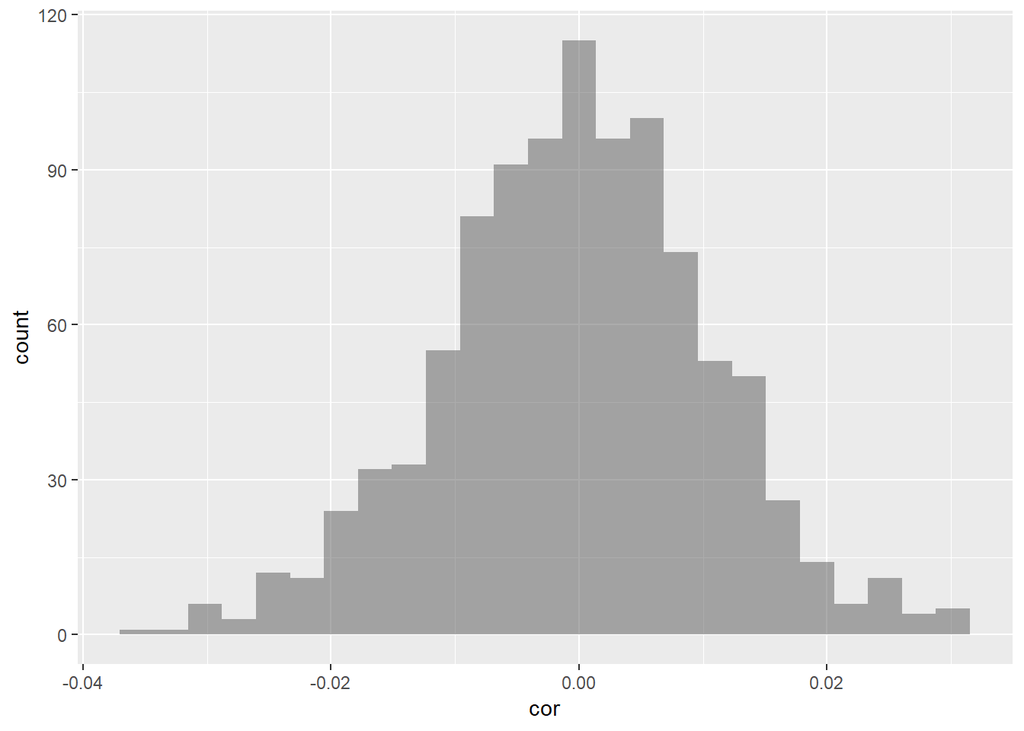

```r
set.seed(50000)
RandomizationCorrelation = do(1000)* cor(Global_Sales~shuffle(Critic_Score), data = Games2.cor)
gf_histogram(~cor, data = RandomizationCorrelation)
```

```r
prop(~cor >= 0.24547, data = RandomizationCorrelation)
```

```
## prop_TRUE
##         0
```

**RELATIONSHIP 2**

An in-depth look into the distribution of global sales for the 3 main platforms: PS4, xbox One and WiiU.

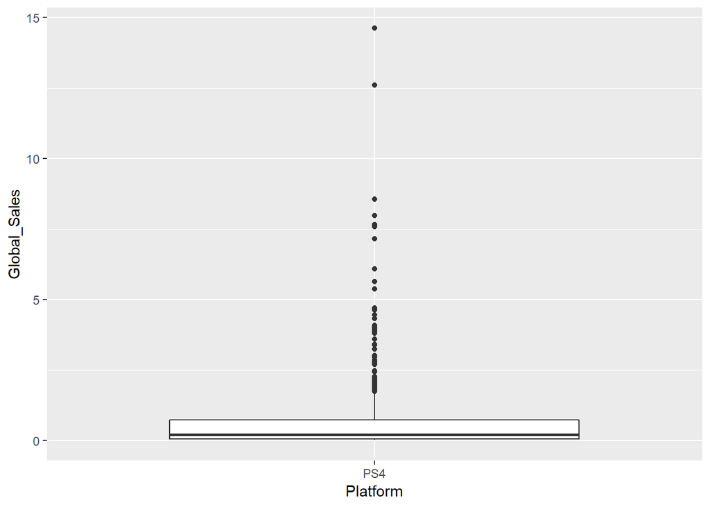

```r
#Sales for PS4
gf_boxplot(Global_Sales ~ Platform, data = filter(Games2, Platform == "PS4"))
```

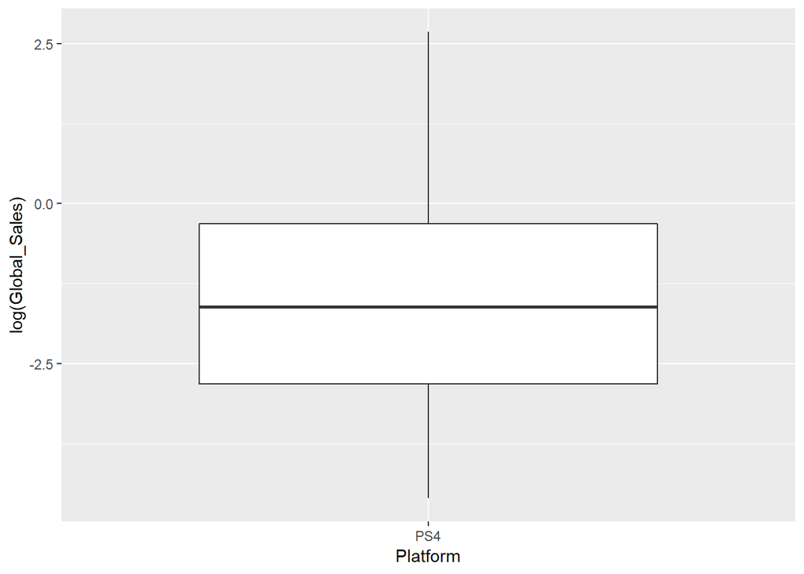

```r
gf_boxplot(log(Global_Sales) ~ Platform, data = filter(Games2, Platform == "PS4"))
```

```r
favstats(~Global_Sales, data = filter(Games2, Platform == "PS4"))
```

```
##   min   Q1 median   Q3   max      mean       sd   n missing
##  0.01 0.06    0.2 0.73 14.63 0.7995674 1.607147 393       0
```

```r
cdata(~Global_Sales, p = 0.9, data = filter(Games2, Platform == "PS4"))
```

```
##       low        hi central.p
##     0.020     3.908     0.900
```

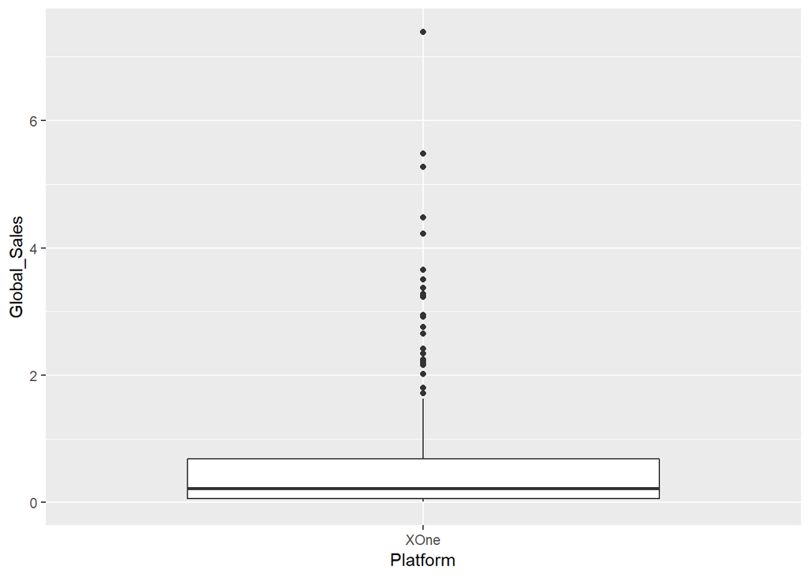

```r
#Sales for Xbox One
gf_boxplot(Global_Sales ~ Platform, data = filter(Games2, Platform == "XOne"))
```

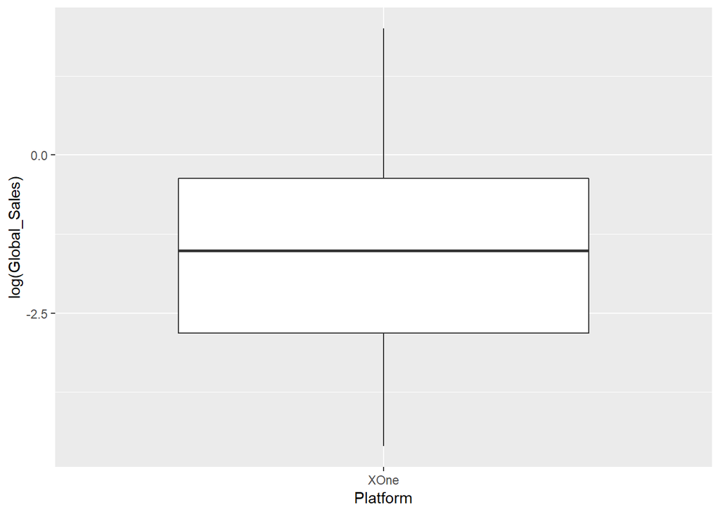

```r
gf_boxplot(log(Global_Sales) ~ Platform, data = filter(Games2, Platform == "XOne"))
```

```r
favstats(~Global_Sales, data = filter(Games2, Platform == "XOne"))
```

```
##   min   Q1 median   Q3  max      mean       sd   n missing
##  0.01 0.06   0.22 0.69 7.39 0.6455061 1.035973 247       0
```

```r
cdata(~Global_Sales, p = 0.9, data = filter(Games2, Platform == "XOne"))
```

```
##       low        hi central.p
##     0.010     2.872     0.900
```

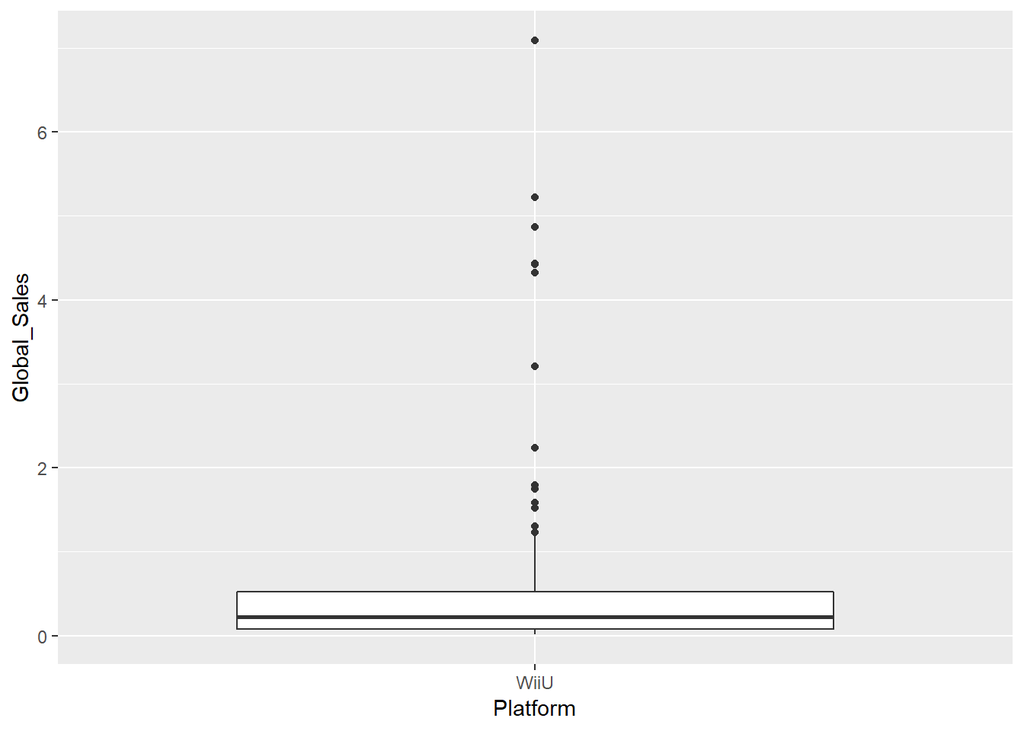

```r
#Sales for WiiU
gf_boxplot(Global_Sales ~ Platform, data = filter(Games2, Platform == "WiiU"))
```

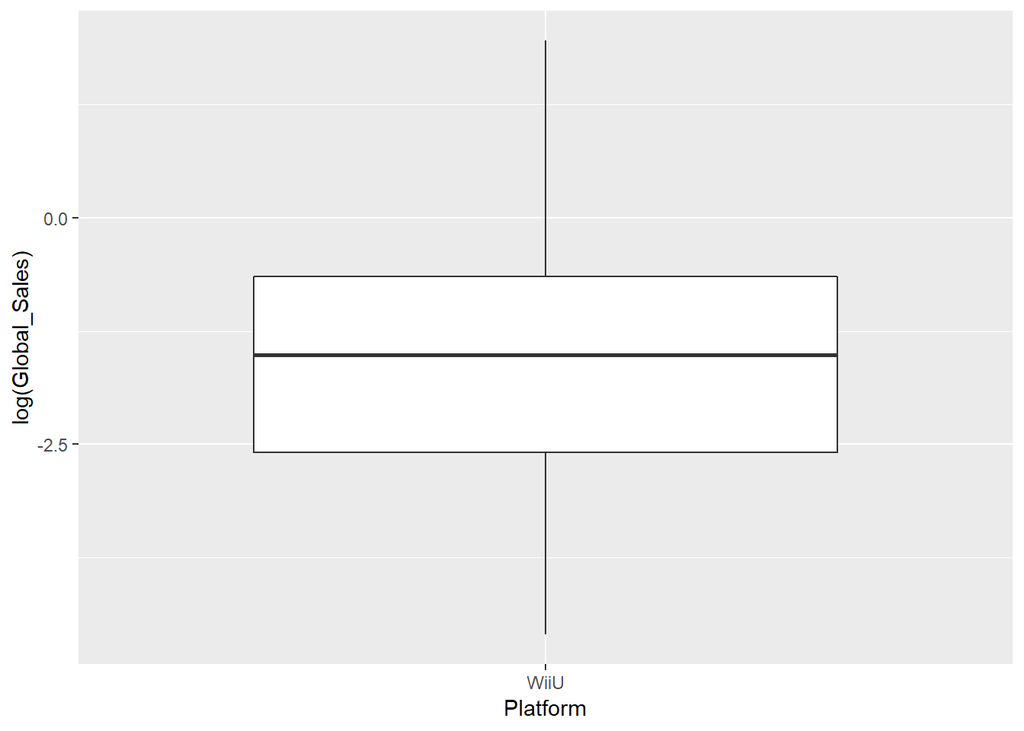

```r
gf_boxplot(log(Global_Sales) ~ Platform, data = filter(Games2, Platform == "WiiU"))
```

```r
favstats(~Global_Sales, data = filter(Games2, Platform == "WiiU"))
```

```
##   min    Q1 median    Q3  max      mean       sd   n missing
##  0.01 0.075   0.22 0.525 7.09 0.5589116 1.058212 147       0
```

```r
cdata(~Global_Sales, p = 0.9, data = filter(Games2, Platform == "WiiU"))
```

```
##       low        hi central.p
##     0.020     2.105     0.900
```

[output not shown]